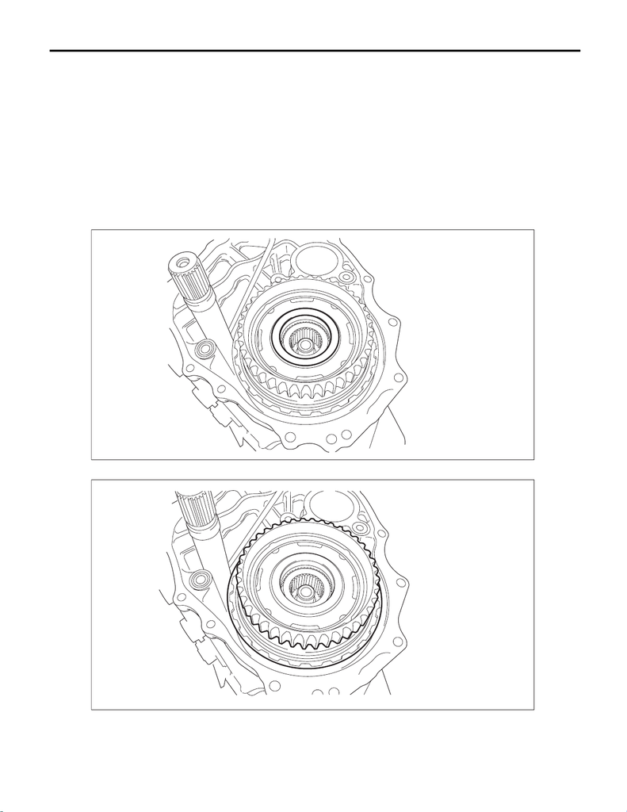

CVT(TR690)-181

Forward Clutch Assembly

CONTINUOUSLY VARIABLE TRANSMISSION

37.Forward Clutch Assembly

A: REMOVAL

1) Remove the transmission from the vehicle. <Ref. to CVT(TR690)-56, REMOVAL, Automatic Transmission

Assembly.>

2) Remove the extension case. <Ref. to CVT(TR690)-142, REMOVAL, Extension Case.>

3) Remove the rear drive shaft. <Ref. to CVT(TR690)-146, REMOVAL, Rear Drive Shaft.>

4) Remove the transfer clutch assembly. <Ref. to CVT(TR690)-151, REMOVAL, Transfer Clutch.>

5) Remove the center differential carrier. <Ref. to CVT(TR690)-154, REMOVAL, Center Differential Carrier.>

6) Remove the transfer reduction driven gear. <Ref. to CVT(TR690)-158, REMOVAL, Transfer Reduction

Driven Gear.>

7) Remove the intermediate case. <Ref. to CVT(TR690)-165, REMOVAL, Intermediate Case.>

8) Remove the thrust needle bearing.

9) Remove the forward clutch assembly.

AT-05237

AT-05238

15WRX_STI_US_EN.book 181 ページ ２０１５年２月１３日 金曜日 午前１１時２０分

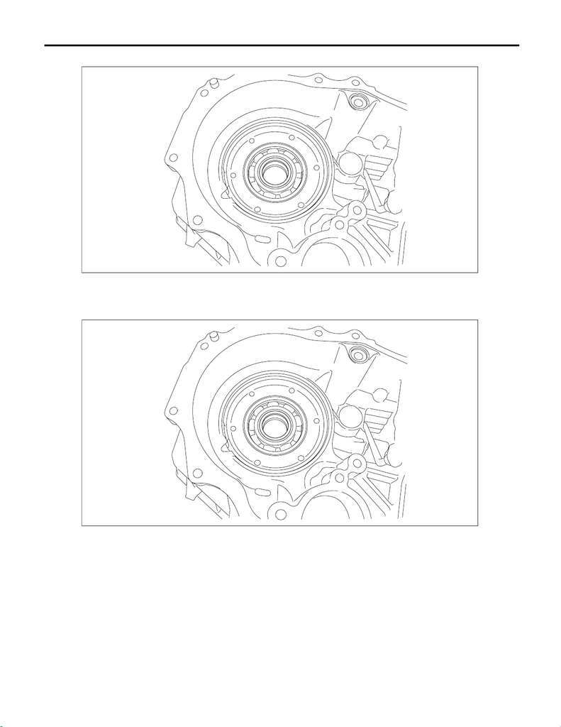

CVT(TR690)-182

Forward Clutch Assembly

CONTINUOUSLY VARIABLE TRANSMISSION

10) Remove the washer.

B: INSTALLATION

1) Select a washer. <Ref. to CVT(TR690)-199, ADJUSTMENT, Forward Clutch Assembly.>

2) Install the selected washer.

AT-05239

AT-05239

15WRX_STI_US_EN.book 182 ページ ２０１５年２月１３日 金曜日 午前１１時２０分

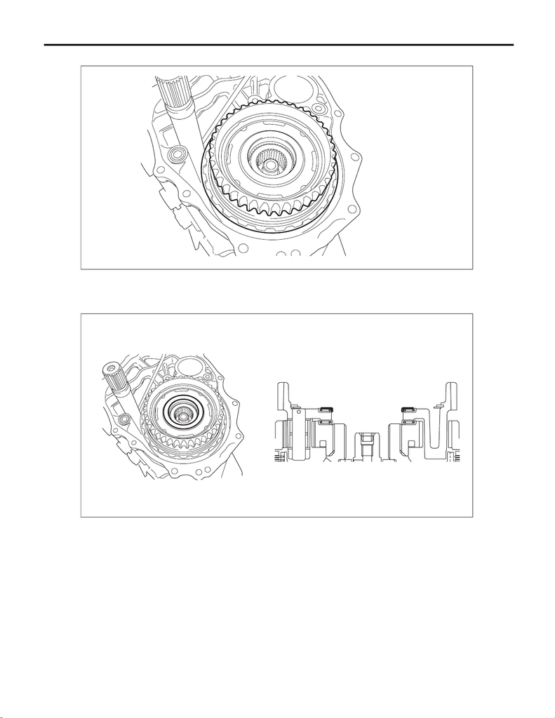

CVT(TR690)-183

Forward Clutch Assembly

CONTINUOUSLY VARIABLE TRANSMISSION

3) Install the forward clutch assembly.

4) Install the thrust needle bearing.

NOTE:

Install the thrust needle bearing in the correct direction.

5) Install the intermediate case. <Ref. to CVT(TR690)-166, INSTALLATION, Intermediate Case.>

6) Install the transfer reduction driven gear assembly. <Ref. to CVT(TR690)-158, INSTALLATION, Transfer

Reduction Driven Gear.>

7) Install the center differential carrier. <Ref. to CVT(TR690)-155, INSTALLATION, Center Differential Car-

rier.>

8) Install the transfer clutch assembly. <Ref. to CVT(TR690)-151, INSTALLATION, Transfer Clutch.>

9) Install the rear drive shaft. <Ref. to CVT(TR690)-146, INSTALLATION, Rear Drive Shaft.>

10) Install the extension case. <Ref. to CVT(TR690)-143, INSTALLATION, Extension Case.>

11) Install the transmission to vehicle. <Ref. to CVT(TR690)-69, INSTALLATION, Automatic Transmission

Assembly.>

AT-05238

AT-05240

15WRX_STI_US_EN.book 183 ページ ２０１５年２月１３日 金曜日 午前１１時２０分

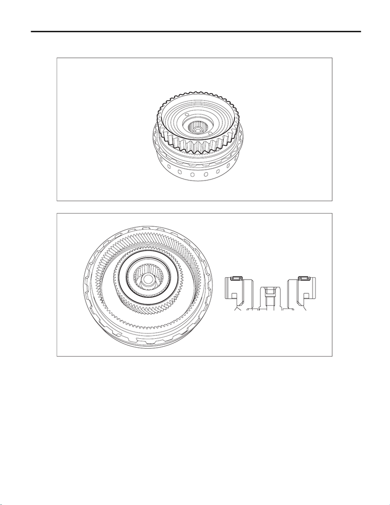

CVT(TR690)-184

Forward Clutch Assembly

CONTINUOUSLY VARIABLE TRANSMISSION

C: DISASSEMBLY

1) Remove the planetary carrier assembly.

2) Remove the thrust needle bearing.

AT-06555

AT-05243

15WRX_STI_US_EN.book 184 ページ ２０１５年２月１３日 金曜日 午前１１時２０分

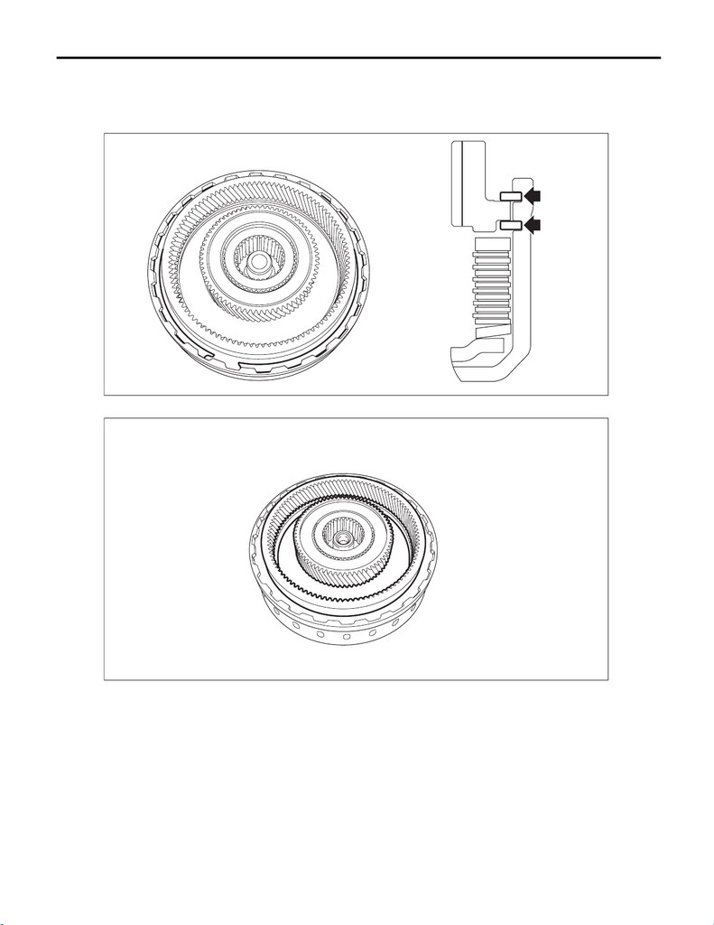

CVT(TR690)-185

Forward Clutch Assembly

CONTINUOUSLY VARIABLE TRANSMISSION

3) Remove the snap ring.

NOTE:

Use marking or labeling to the upper snap ring for measurement of the snap ring thickness when selecting

the retaining plate.

4) Remove the internal gear.

AT-05244

AT-05245

15WRX_STI_US_EN.book 185 ページ ２０１５年２月１３日 金曜日 午前１１時２０分

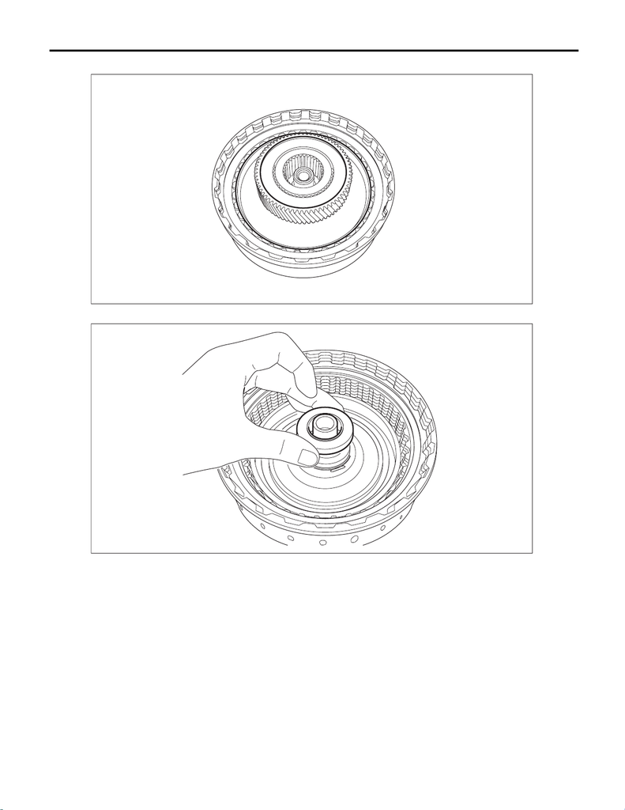

CVT(TR690)-186

Forward Clutch Assembly

CONTINUOUSLY VARIABLE TRANSMISSION

5) Remove the sun gear.

6) Remove the washer.

AT-05246

AT-05256

15WRX_STI_US_EN.book 186 ページ ２０１５年２月１３日 金曜日 午前１１時２０分

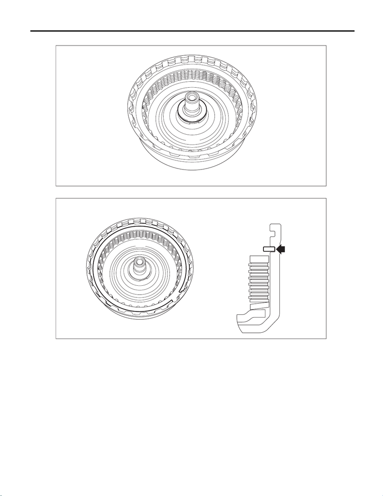

CVT(TR690)-187

Forward Clutch Assembly

CONTINUOUSLY VARIABLE TRANSMISSION

7) Remove the thrust needle bearing.

8) Remove the snap ring.

AT-05247

AT-05248

15WRX_STI_US_EN.book 187 ページ ２０１５年２月１３日 金曜日 午前１１時２０分

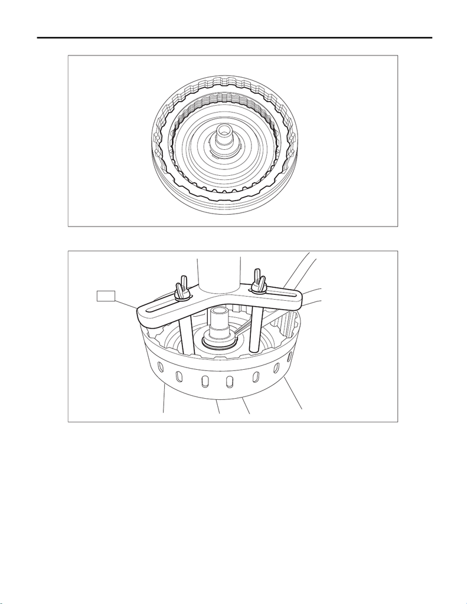

CVT(TR690)-188

Forward Clutch Assembly

CONTINUOUSLY VARIABLE TRANSMISSION

9) Remove the retaining plate, drive plate, driven plate and dish plate.

10) Using the ST, remove the snap ring.

ST 18762AA001 COMPRESSOR SPECIAL TOOL

AT-05249

AT-05250

ST

15WRX_STI_US_EN.book 188 ページ ２０１５年２月１３日 金曜日 午前１１時２０分

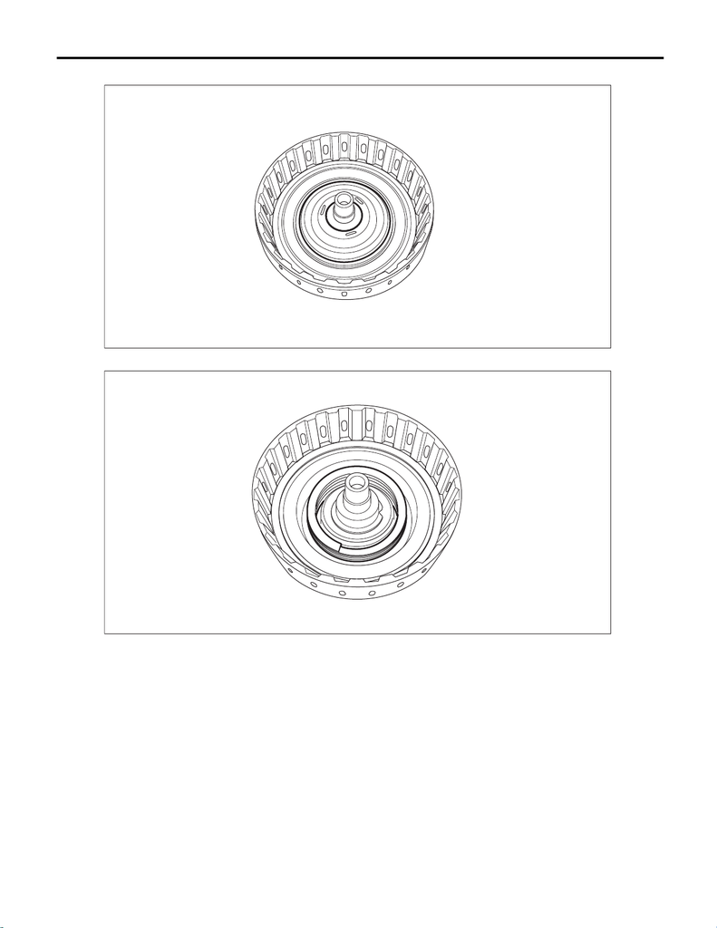

CVT(TR690)-189

Forward Clutch Assembly

CONTINUOUSLY VARIABLE TRANSMISSION

11) Remove the forward clutch piston retainer.

12) Remove the return spring.

AT-05251

AT-05252

15WRX_STI_US_EN.book 189 ページ ２０１５年２月１３日 金曜日 午前１１時２０分

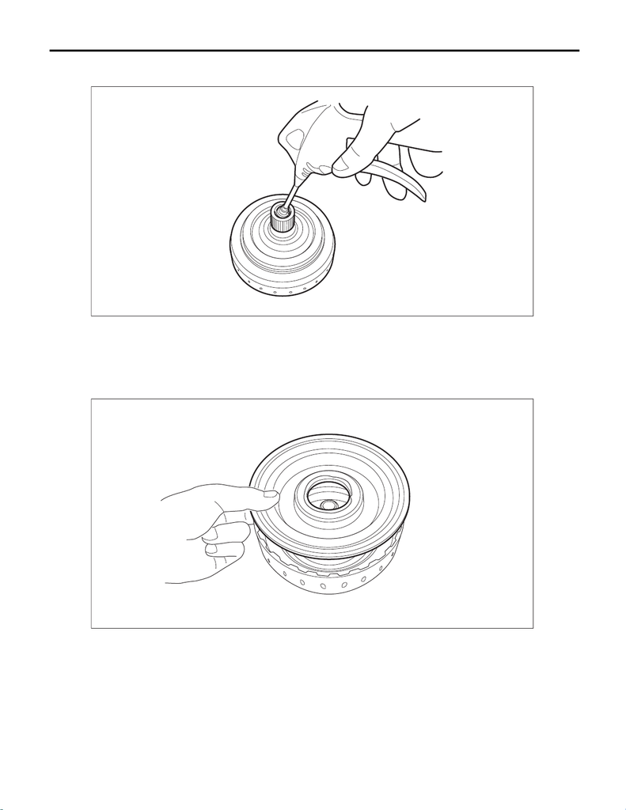

CVT(TR690)-190

Forward Clutch Assembly

CONTINUOUSLY VARIABLE TRANSMISSION

13) Remove the forward clutch piston by blowing compressed air intermittently from end of forward clutch

drum.

D: ASSEMBLY

1) Install the forward clutch piston to forward clutch drum.

NOTE:

• Apply CVTF to the seal of forward clutch piston.

• Insert it all the way to the end.

AT-05253

AT-05254

15WRX_STI_US_EN.book 190 ページ ２０１５年２月１３日 金曜日 午前１１時２０分

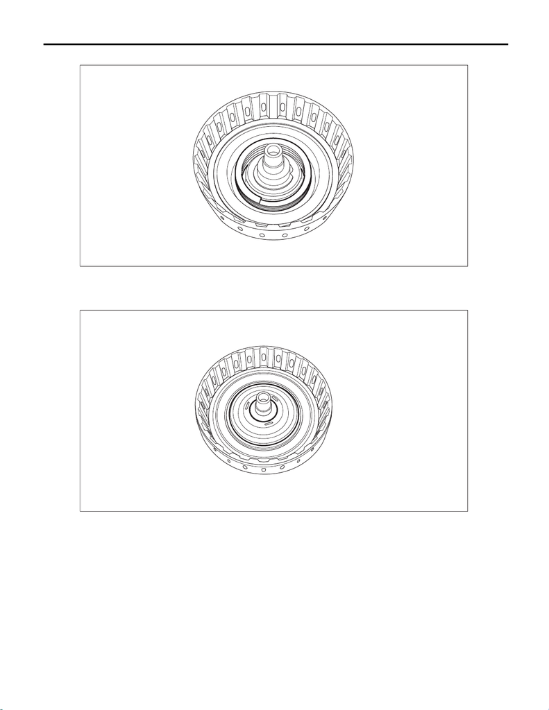

CVT(TR690)-191

Forward Clutch Assembly

CONTINUOUSLY VARIABLE TRANSMISSION

2) Install the return spring.

3) Install the forward clutch piston retainer.

NOTE:

Apply CVTF to the sealing area of forward clutch piston retainer.

AT-05252

AT-05251

15WRX_STI_US_EN.book 191 ページ ２０１５年２月１３日 金曜日 午前１１時２０分

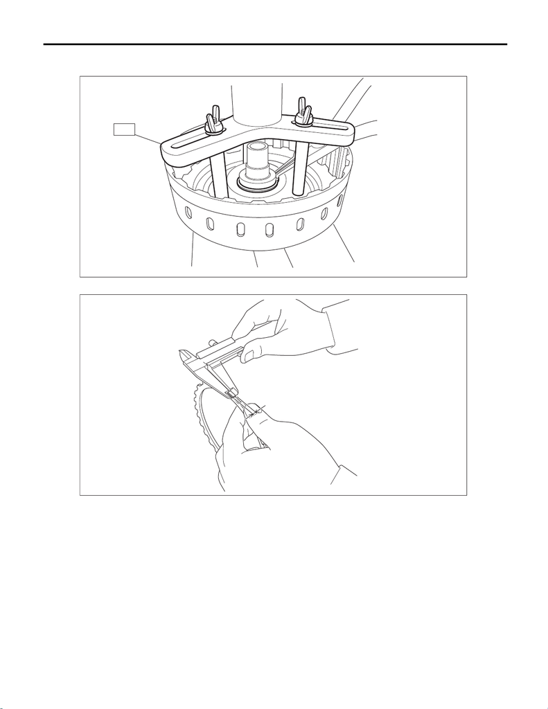

CVT(TR690)-192

Forward Clutch Assembly

CONTINUOUSLY VARIABLE TRANSMISSION

4) Compress the return spring using the ST to install the snap ring.

ST 18762AA001 COMPRESSOR SPECIAL TOOL

5) Measure thickness “A” of the retaining plate installed.

AT-05250

ST

AT-07882

A

15WRX_STI_US_EN.book 192 ページ ２０１５年２月１３日 金曜日 午前１１時２０分

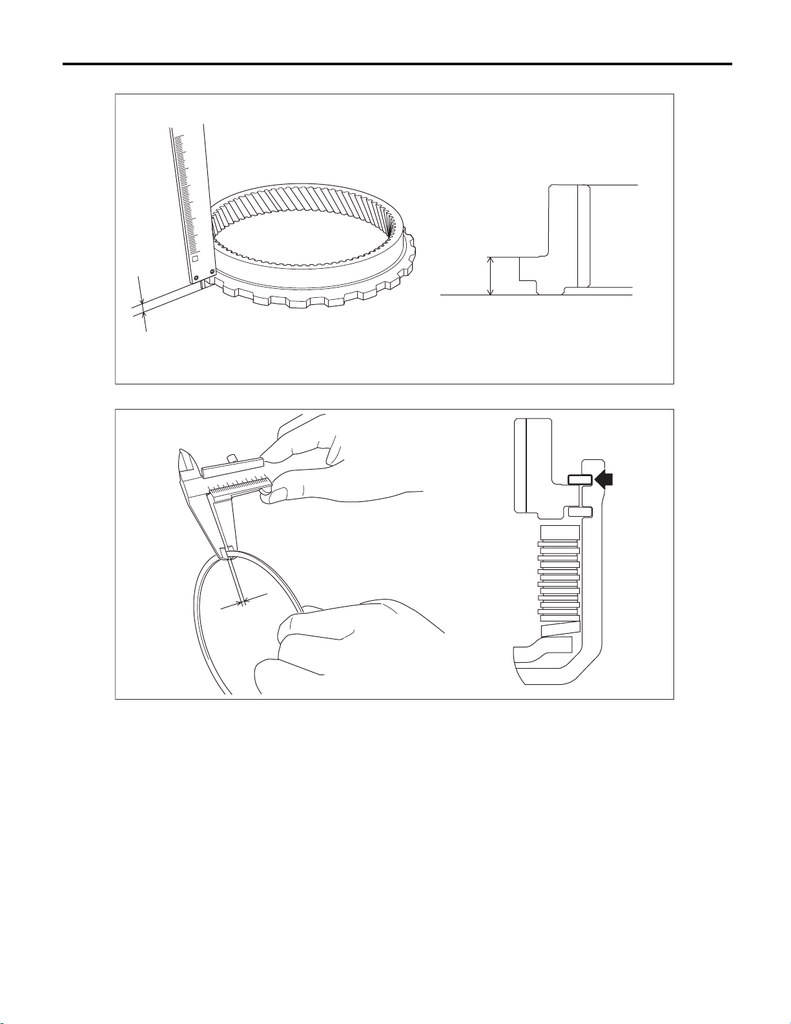

CVT(TR690)-193

Forward Clutch Assembly

CONTINUOUSLY VARIABLE TRANSMISSION

6) Measure thickness “B” of the internal gear on a surface plate.

7) Measure thickness “C” of labelled or marked snap ring.

AT-07883

B

B

AT-07884

C

15WRX_STI_US_EN.book 193 ページ ２０１５年２月１３日 金曜日 午前１１時２０分

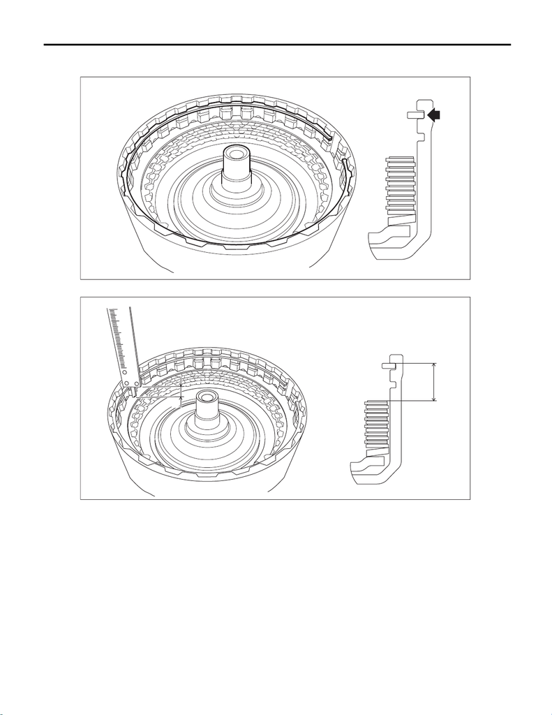

CVT(TR690)-194

Forward Clutch Assembly

CONTINUOUSLY VARIABLE TRANSMISSION

8) Install the dish plate, drive plate and driven plate.

9) Install the snap ring at the location (upper groove) indicated in the figure.

10) Measure depth “D” of snap ring and driven plate while lifting the snap ring.

AT-05261

AT-07885

D

D

15WRX_STI_US_EN.book 194 ページ ２０１５年２月１３日 金曜日 午前１１時２０分

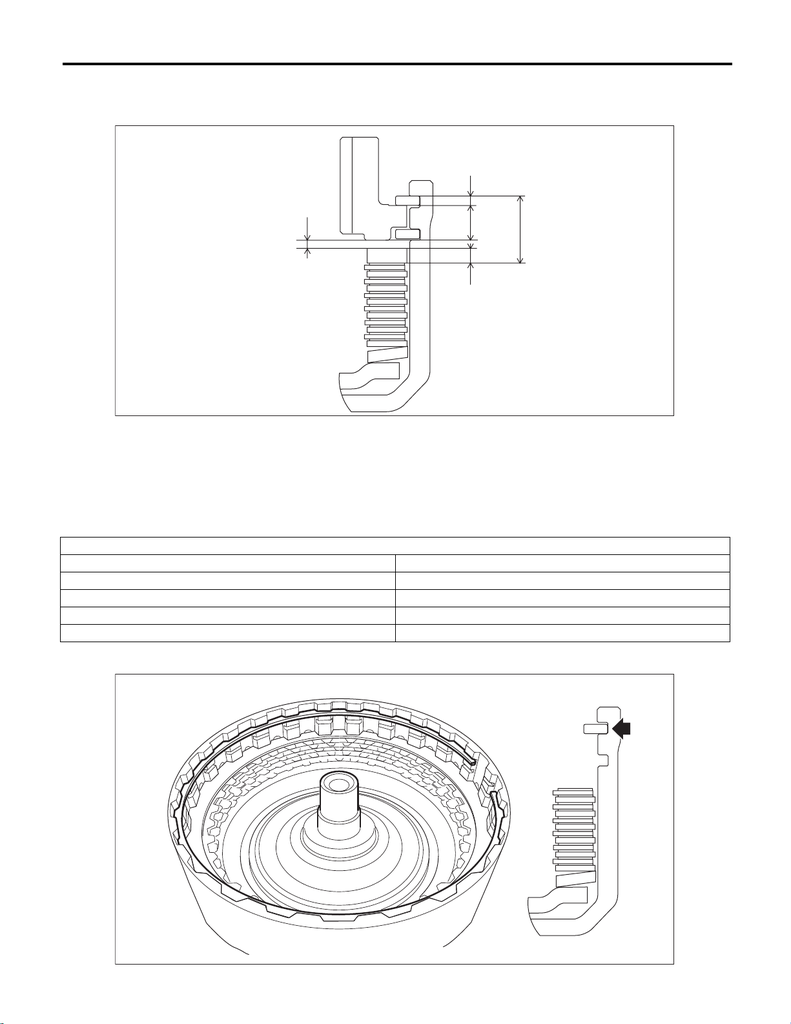

CVT(TR690)-195

Forward Clutch Assembly

CONTINUOUSLY VARIABLE TRANSMISSION

11) Calculate clearance “T” from internal gear to retaining plate with the obtained value from step 5) through

step 10).

Formula: T mm (in) = D – A – B – C

12) If the value “T” obtained from step 11) exceeds the limit for use, replace the drive plate and driven plate

with new parts and select the retaining plate within the initial standard value.

Initial standard:

1.2 — 1.6 mm (0.047 — 0.063 in)

Limit thickness:

2.4 mm (0.09 in)

13) Remove the snap ring.

Retaining plate

Item number Thickness mm (in)

31567AB670 3.2 (0.126)

31567AB660 3.0 (0.118)

31567AB650 2.8 (0.110)

31567AB640 2.6 (0.102)

AT-07886

A

T

D

B

C

AT-05261

15WRX_STI_US_EN.book 195 ページ ２０１５年２月１３日 金曜日 午前１１時２０分

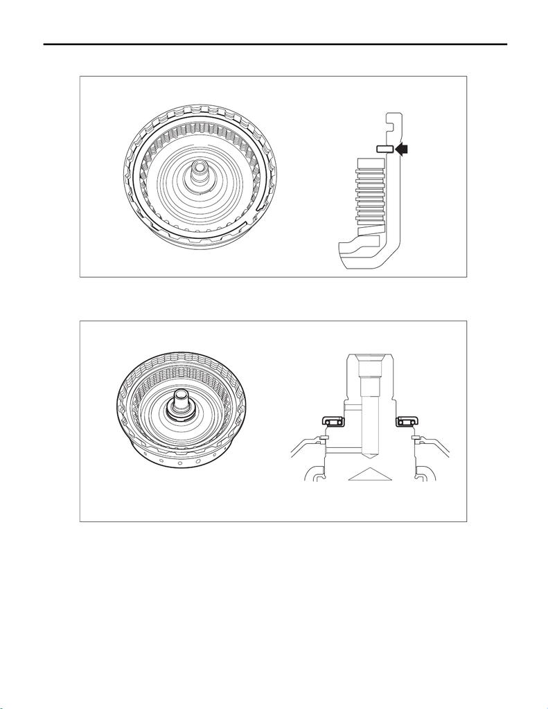

CVT(TR690)-196

Forward Clutch Assembly

CONTINUOUSLY VARIABLE TRANSMISSION

14) Replace with the selected retaining plate to install.

15) Install the snap ring to the lower groove.

16) Install the thrust needle bearing.

NOTE:

Install the thrust needle bearing in the correct direction.

AT-05248

AT-05255

15WRX_STI_US_EN.book 196 ページ ２０１５年２月１３日 金曜日 午前１１時２０分

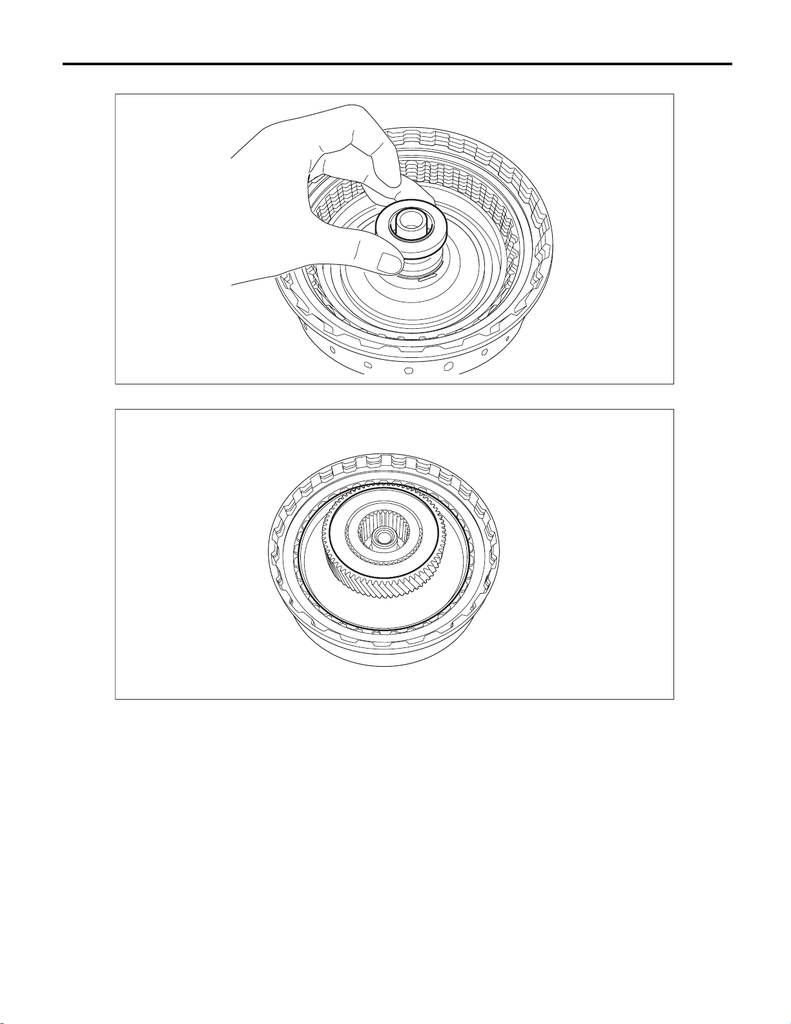

CVT(TR690)-197

Forward Clutch Assembly

CONTINUOUSLY VARIABLE TRANSMISSION

17) Install the washer.

18) Install the sun gear.

AT-05256

AT-05246

15WRX_STI_US_EN.book 197 ページ ２０１５年２月１３日 金曜日 午前１１時２０分

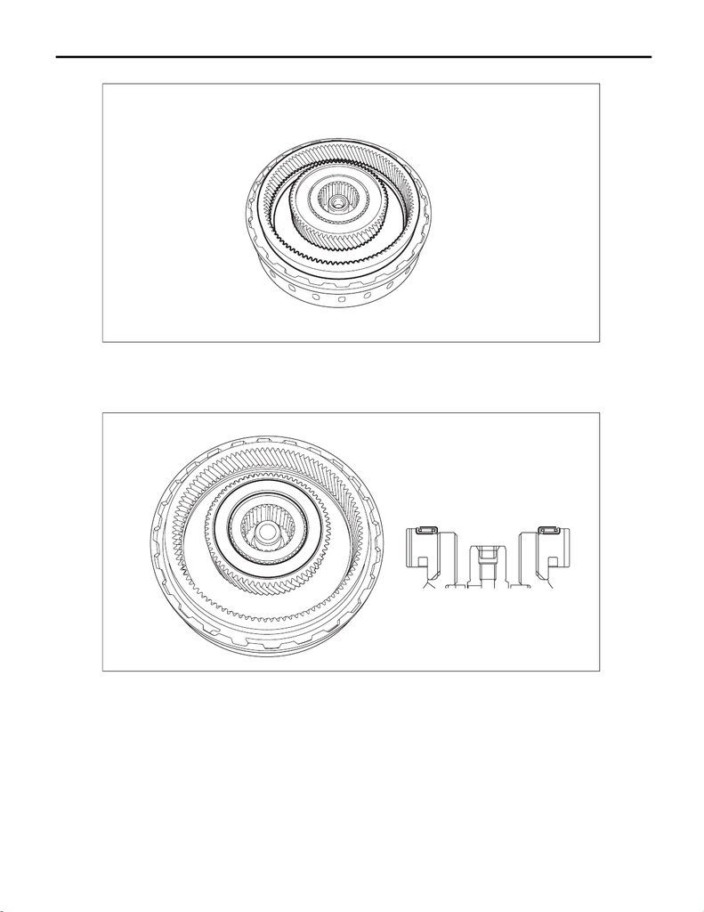

CVT(TR690)-198

Forward Clutch Assembly

CONTINUOUSLY VARIABLE TRANSMISSION

19) Install the internal gear.

20) Install the snap ring.

21) Install the thrust needle bearing.

NOTE:

Make sure to install in the right direction.

AT-05245

AT-05243

15WRX_STI_US_EN.book 198 ページ ２０１５年２月１３日 金曜日 午前１１時２０分

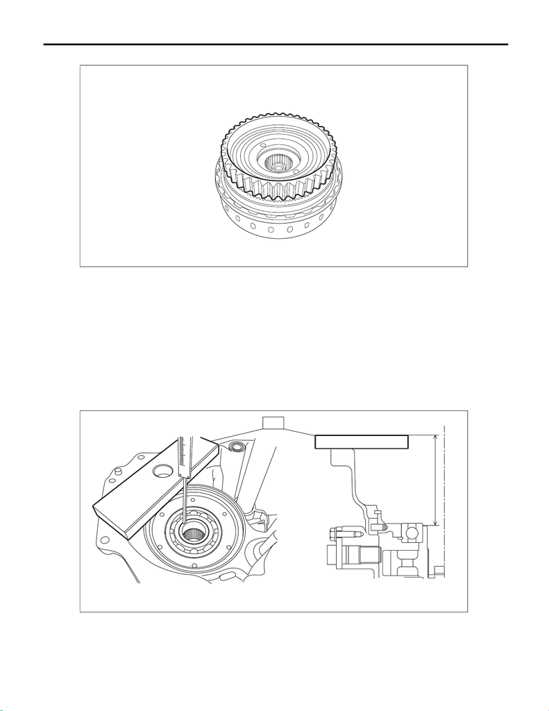

CVT(TR690)-199

Forward Clutch Assembly

CONTINUOUSLY VARIABLE TRANSMISSION

22) Install the planetary carrier assembly.

E: INSPECTION

• Check the forward clutch drum, internal gear, sun gear and forward clutch piston lip for wear or damage.

• Inspect the drive plate facing for wear and damage.

• Check the driven plate for discoloration (burnt color).

• Check for worn snap ring, fatigue or damaged return spring or deformed spring retainer.

• Make sure the clearance between retaining plate and internal gear of forward clutch is within the limit. If it

exceeds the standard, replace the forward clutch assembly. <Ref. to CVT(TR690)-190, ASSEMBLY, For-

ward Clutch Assembly.>

F: ADJUSTMENT

1) Measure depth “A” from the ST upper face to the washer catch surface.

ST 398643600 GAUGE

2) Install the forward clutch assembly to intermediate case.

AT-06555

AT-07887

ST

A

15WRX_STI_US_EN.book 199 ページ ２０１５年２月１３日 金曜日 午前１１時２０分

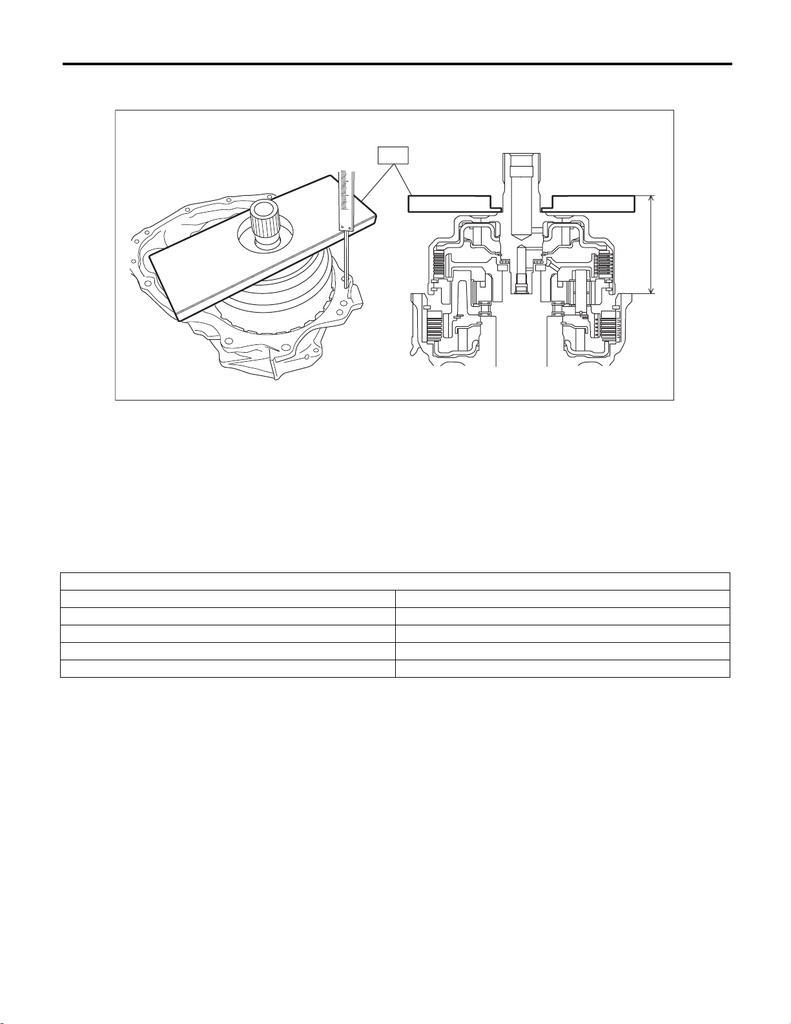

CVT(TR690)-200

Forward Clutch Assembly

CONTINUOUSLY VARIABLE TRANSMISSION

3) Setting the ST, measure height “B” from the ST upper side to the intermediate case mating surface.

ST 499575600 GAUGE

4) Obtain the thickness of washer using the following formula.

Calculation formula:

T (mm) = (A – 15) – (B – 15) – (0.35 — 0.70)

[T (in) = (A – 0.591) – (B – 0.591) – (0.014 — 0.028)]

T: Washer thickness

A: Depth from the ST upper face to the washer catch surface

B: Height from the upper surface of the ST to the mating surface of the intermediate case

15 mm (0.591 in): Thickness of ST

0.35 — 0.70 mm (0.014 — 0.028 in): Clearance

5) Select the washer to meet the value “T” obtained from step 4).

Washer

Part No. Washer thickness mm (in)

803034040 1.0 (0.039)

803034041 1.2 (0.047)

803034042 1.4 (0.055)

803034043 1.6 (0.063)

AT-07888

ST

B

15WRX_STI_US_EN.book 200 ページ ２０１５年２月１３日 金曜日 午前１１時２０分